# Script 34: Predict cell types in bulk samples

Compiled: June 26, 2024

> This script predicts proportions of blood cell-types from DNAm data using the IDOL and IDOLext algorithms, and also uses MuSiC alongside a scRNA reference to deconvolute bulk RNAseq data.

# Setup

Load required packages

```r
library(rlang)
library(htmltools)
library(rmarkdown)
library(cli)
library(tidyverse)
library(DNAmArray)
library(lubridate)
library(Biobase)
library(MuSiC)
library(SummarizedExperiment)
library(minfi)
library(ExperimentHub)
library(FlowSorted.Blood.EPIC)
library(FlowSorted.BloodExtended.EPIC)
library(IlluminaHumanMethylationEPICmanifest)
library(IlluminaHumanMethylation450kmanifest)
library(IlluminaHumanMethylationEPICanno.ilm10b4.hg19)
```

Load DNA methylation data

```r
load("../GOTO_Data/GOTO_targets-filtered.Rdata")
load("../GOTO_Data/GOTO_methData-filtered.Rdata")
load("../GOTO_Data/Processing/GOTO_RGset-unfiltered.Rdata")
colnames(methData) <- targets$Basename

methData
```

```
## class: SummarizedExperiment
## dim: 755777 534
## metadata(0):
## assays(1): beta
## rownames(755777): cg18478105 cg09835024 ... cg10633746 cg12623625
## rowData names(57): cpg chr ... MASK_extBase MASK_general
## colnames(534): 203527980082_R01C01 203527980082_R02C01 ...
##   203550300093_R07C01 203550300093_R08C01
## colData names(45): DNA_labnr IOP2_ID ... m1_macro m2_macro
```

```r
RGset
```

```
## class: RGChannelSetExtended
## dim: 1051815 534
## metadata(0):
## assays(5): Green Red GreenSD RedSD NBeads
## rownames(1051815): 1600101 1600111 ... 99810990 99810992
## rowData names(0):
## colnames(534): 203527980082_R01C01 203527980082_R02C01 ...
##   203550300093_R07C01 203550300093_R08C01
## colData names(19): DNA_labnr IOP2_ID ... Basename filenames
## Annotation
##   array: IlluminaHumanMethylationEPIC
##   annotation: ilm10b4.hg19
```

Load measured cell count data alongside other variables on medication use and start dates.

```r
blood_df <- read_csv("../GOTO_Data/Cell_Counts/Blood/GOTO_Cellcounts-Medication_20210401.csv")
```

# Measured Cell Counts

Blood cell counts were measured using a differential test.

Make visit date a date

```r
blood_df$visit_date <- as_date(blood_df$visit_date,
                               format = "%m/%d/%Y")
```

Create start date

```r
# Save targets order
blood_df$num <- 1:nrow(blood_df)

# Arrange by ID
blood_df <- blood_df %>% arrange(IOP2_ID)

# Create new df
start_date <- blood_df

# Select baseline visit dates
start_date <- start_date %>%
  filter(timepoint == 0) %>%
  dplyr::select(visit_date)

# Repeat each date twice
start_date <- data.frame(start_date = rep(
  start_date$visit_date, each=2
))

# Add to original targets
blood_df <- cbind(blood_df, start_date)

# Arrange back to original order
blood_df <- blood_df %>% arrange(num)
```

Create factors

```r
blood_df$IOP2_ID <- as.factor(blood_df$IOP2_ID)
blood_df$timepoint <- as.factor(blood_df$timepoint)
```

Save ID list and timepoint order from `methData`

```r
ID_list <- targets %>% dplyr::select(IOP2_ID, timepoint)
dim(ID_list)
```

```
## [1] 534   2
```

Merge the imported cell count data to get the same order.

```r
blood_df <- left_join(ID_list, blood_df, by=c("IOP2_ID", "timepoint"))
```

Remove the ordering variables

```r
blood_df <- blood_df %>%
  dplyr::select(start_date,
                cc_eos_perc, cc_baso_perc, cc_neut_perc,
                cc_lymph_perc, cc_mono_perc)
```

Combine data frames

```r
targets <- cbind(targets, blood_df)
dim(targets)
```

```
## [1] 534  51
```

Remove for non blood tissues

```r
targets <- targets %>%
  mutate(
    cc_eos_perc = ifelse(tissue != "fasted blood", NA, cc_eos_perc),
    cc_baso_perc = ifelse(tissue != "fasted blood", NA, cc_baso_perc),
    cc_neut_perc = ifelse(tissue != "fasted blood", NA, cc_neut_perc),
    cc_lymph_perc = ifelse(tissue != "fasted blood", NA, cc_lymph_perc),
    cc_mono_perc = ifelse(tissue != "fasted blood", NA, cc_mono_perc)
  )
```

Save variables of interest

```r
targets <- targets %>%
  dplyr::select(DNA_labnr, IOP2_ID, tissue, timepoint,
                age, sex, bmi, op_status,
                start_date, visit_date, isolationdate,
                plate, well, array_n, array_row,
                Basename,
                cc_blood_meas_eos = cc_eos_perc,
                cc_blood_meas_baso = cc_baso_perc,
                cc_blood_meas_neut = cc_neut_perc,
                cc_blood_meas_lymph = cc_lymph_perc,
                cc_blood_meas_mono = cc_mono_perc, everything())
```

# MuSiC

### Expression Set for scRNA

Read in the scRNA data from GSE143704

```r
sc_blood <- read.table('../GOTO_Data/Cell_Counts/Blood/scRNA-blood_GSE143704.tsv', sep = "\t")
```

Save cell names

```r
cell_names <- as.data.frame(t(sc_blood[1,-1]))
colnames(cell_names) <- "Cell"
```

Remove the first row with cell names

```r
sc_blood <- as.data.frame(sc_blood[-1,])
```

Save rownames

```r
gene_names <- sc_blood[,1]
```

Remove GeneSymbol column

```r
sc_blood <- sc_blood[,-1]
```

Create an expression matrix

```r
sc_blood <- data.frame(apply(sc_blood, 2, as.numeric))
```

Add rownames

```r
rownames(sc_blood) <- gene_names
```

Make column names

```r
colnames(sc_blood) <- str_pad(1:ncol(sc_blood), width=3, pad="0")
```

Look

```r
sc_blood[1:5, 1:5]
```

```
##            001 002 003 004 005
## OR4F5        0   0   0   0   0
## FO538757.3   0   0   0   0   0
## FO538757.2   0   0   0   0   0
## OR4F29       0   0   0   0   0
## OR4F16       0   0   0   0   0
```

Add sample labels to cell_names

```r
cell_names$Sample <- str_pad(1:ncol(sc_blood), width=3, pad="0")
rownames(cell_names) <- str_pad(1:ncol(sc_blood), width=3, pad="0")
head(cell_names)
```

```
##     Cell Sample
## 001  BNK    001
## 002  BNK    002
## 003  BNK    003
## 004  BNK    004
## 005  BNK    005
## 006  BNK    006
```

### GOTO Expresssion Data

Load functions

```r
source('../GOTO_Data/RNAseq/goto.rnaseq.functions.R')
```

Load in RNAseq from complete blood pairs

```r
pathIN_dat <- "../GOTO_Data/RNAseq/merge.gene.counts_biopet_13052016.RData"
pathIN_cov <- "../GOTO_Data/RNAseq/datasheet_RNAseq_blood_V2.csv"

filt.samp <- "tissue_blood|qc_sexswitch|qc_multdim2|qc_rep1|complete_pairs"

goto_exp <- read.gotornaseq(pathIN_dat = pathIN_dat, pathIN_cov, filt.samp = filt.samp, quiet = FALSE)
```

```
## ||| PREPARING GOTO RNASEQ DATA
## || READING DATA
## | Loading RNASEQ .. OK!
##    [555 samples x 56520 features]
## | Reading COVARIATES .. OK!
##    [maintaining 379 samples x 84 features]
## | Merging data .. OK!
##    [555 samples x 56604 features]
## || SUBSETTING SAMPLES
## | Subsetting SAMPLES on ['tissue_blood']; PASS: 379 out of 555
## | Subsetting SAMPLES on ['qc_sexswitch']; PASS: 379 out of 379
## | Subsetting SAMPLES on ['qc_multdim2']; PASS: 379 out of 379
## | Subsetting SAMPLES on ['qc_rep1']; PASS: 376 out of 379
## | Subsetting SAMPLES on ['complete_pairs']; PASS: 376 out of 376
## | DONE!
```

```r
goto_exp <- goto_exp[["dat"]]
```

Filter pre-challenge samples and save counts

```r
goto_exp <- goto_exp %>%
  dplyr::filter(nutridrink == 0) %>%
  dplyr::select(sampID2, intervention,
                       starts_with('ENS')) %>%
  mutate(
  ID = str_c(sampID2, '_', intervention)
)
```

Save IDs

```r
ID_name <- goto_exp$ID
ID_df <- data.frame(Sample = ID_name)
rownames(ID_df) = ID_name
```

Remove non-gene variables

```r
goto_exp <- goto_exp %>% dplyr::select(-ID, -sampID2, -intervention)
goto_exp <- as.data.frame(t(goto_exp))
colnames(goto_exp) <- ID_name
```

Map to gene name

```r
ens2gene <- cinaR::grch37
m <- match(rownames(goto_exp), ens2gene$ensgene)
mapped.genes <- ens2gene$symbol[m]

removed.genes <- duplicated(mapped.genes) | is.na(mapped.genes) | grepl("^MT", mapped.genes)
goto_exp <- goto_exp[!removed.genes,]
rownames(goto_exp) <- mapped.genes[!removed.genes]
```

### Subset

```r
goto_exp <- goto_exp[rownames(goto_exp) %in% rownames(sc_blood),]
sc_blood <- sc_blood[rownames(sc_blood) %in% rownames(goto_exp),]
```

### Expression Sets

Create an expression set for the single cell data

```r
C.eset <- Biobase::ExpressionSet(
  assayData = as.matrix(sc_blood),
  phenoData = Biobase::AnnotatedDataFrame(cell_names))
C.eset
```

```
## ExpressionSet (storageMode: lockedEnvironment)
## assayData: 18531 features, 7643 samples
##   element names: exprs
## protocolData: none
## phenoData
##   sampleNames: 001 002 ... 7643 (7643 total)
##   varLabels: Cell Sample
##   varMetadata: labelDescription
## featureData: none
## experimentData: use 'experimentData(object)'
## Annotation:
```

Make expression set for bulk RNAseq from GOTO

```r
T.eset <- Biobase::ExpressionSet(assayData = as.matrix(goto_exp),
            phenoData = Biobase::AnnotatedDataFrame(ID_df))
T.eset
```

```
## ExpressionSet (storageMode: lockedEnvironment)
## assayData: 18531 features, 183 samples
##   element names: exprs
## protocolData: none
## phenoData
##   sampleNames: 61482_1 62340_0 ... 61789_0 (183 total)
##   varLabels: Sample
##   varMetadata: labelDescription
## featureData: none
## experimentData: use 'experimentData(object)'
## Annotation:
```

### MuSiC

Deconvolute

```r
deconv <- music_prop(
  bulk.eset = T.eset,
  sc.eset = C.eset,
  clusters = 'Cell',
  markers = NULL,
  normalize = FALSE,
  samples = 'Sample',
  verbose = F)$Est.prop.weighted

summary(deconv)
```

```
##       BNK         CD4T               CD8T             claM              CLP
##  Min.   :0   Min.   :0.000000   Min.   :0.0000   Min.   :0.00000   Min.   :0
##  1st Qu.:0   1st Qu.:0.000000   1st Qu.:0.1224   1st Qu.:0.00000   1st Qu.:0
##  Median :0   Median :0.000000   Median :0.1765   Median :0.00000   Median :0
##  Mean   :0   Mean   :0.008223   Mean   :0.1808   Mean   :0.01352   Mean   :0
##  3rd Qu.:0   3rd Qu.:0.000000   3rd Qu.:0.2293   3rd Qu.:0.02043   3rd Qu.:0
##  Max.   :0   Max.   :0.421140   Max.   :0.5105   Max.   :0.13934   Max.   :0
##       cMOP                CMP         ery                 GMP
##  Min.   :0.0000000   Min.   :0   Min.   :0.0000000   Min.   :0.000e+00
##  1st Qu.:0.0000000   1st Qu.:0   1st Qu.:0.0000000   1st Qu.:0.000e+00
##  Median :0.0000000   Median :0   Median :0.0004511   Median :0.000e+00
##  Mean   :0.0007752   Mean   :0   Mean   :0.0014828   Mean   :3.112e-06
##  3rd Qu.:0.0004220   3rd Qu.:0   3rd Qu.:0.0023557   3rd Qu.:0.000e+00
##  Max.   :0.0404196   Max.   :0   Max.   :0.0156175   Max.   :3.736e-04
##       hMDP                HSC         immB              interM
##  Min.   :0.0000000   Min.   :0   Min.   :0.000000   Min.   :0.03935
##  1st Qu.:0.0000000   1st Qu.:0   1st Qu.:0.001233   1st Qu.:0.17359
##  Median :0.0000000   Median :0   Median :0.006863   Median :0.21533
##  Mean   :0.0002782   Mean   :0   Mean   :0.010768   Mean   :0.20676
##  3rd Qu.:0.0000000   3rd Qu.:0   3rd Qu.:0.013084   3rd Qu.:0.24116
##  Max.   :0.0157085   Max.   :0   Max.   :0.174863   Max.   :0.33207
##      kineNK       LMPP      matureN            memB        MEP
##  Min.   :0   Min.   :0   Min.   :0.1228   Min.   :0   Min.   :0
##  1st Qu.:0   1st Qu.:0   1st Qu.:0.2630   1st Qu.:0   1st Qu.:0
##  Median :0   Median :0   Median :0.2948   Median :0   Median :0
##  Mean   :0   Mean   :0   Mean   :0.2931   Mean   :0   Mean   :0
##  3rd Qu.:0   3rd Qu.:0   3rd Qu.:0.3260   3rd Qu.:0   3rd Qu.:0
##  Max.   :0   Max.   :0   Max.   :0.4218   Max.   :0   Max.   :0
##      metaN              MLP         MPP         myeN
##  Min.   :0.08611   Min.   :0   Min.   :0   Min.   :0.000000
##  1st Qu.:0.20954   1st Qu.:0   1st Qu.:0   1st Qu.:0.000000
##  Median :0.24646   Median :0   Median :0   Median :0.000000
##  Mean   :0.24488   Mean   :0   Mean   :0   Mean   :0.000529
##  3rd Qu.:0.28270   3rd Qu.:0   3rd Qu.:0   3rd Qu.:0.000000
##  Max.   :0.37715   Max.   :0   Max.   :0   Max.   :0.063761
##       naiB                NKP         nonM              plasma
##  Min.   :0.0000000   Min.   :0   Min.   :0.000000   Min.   :0.000e+00
##  1st Qu.:0.0000000   1st Qu.:0   1st Qu.:0.000000   1st Qu.:0.000e+00
##  Median :0.0000000   Median :0   Median :0.000000   Median :4.373e-05
##  Mean   :0.0008892   Mean   :0   Mean   :0.006094   Mean   :3.212e-04
##  3rd Qu.:0.0000000   3rd Qu.:0   3rd Qu.:0.002170   3rd Qu.:4.158e-04
##  Max.   :0.0920783   Max.   :0   Max.   :0.098688   Max.   :4.052e-03
##       preB        preM              proB        proN        regB
##  Min.   :0   Min.   :0.00000   Min.   :0   Min.   :0   Min.   :0.000e+00
##  1st Qu.:0   1st Qu.:0.01988   1st Qu.:0   1st Qu.:0   1st Qu.:0.000e+00
##  Median :0   Median :0.02970   Median :0   Median :0   Median :0.000e+00
##  Mean   :0   Mean   :0.03143   Mean   :0   Mean   :0   Mean   :7.168e-06
##  3rd Qu.:0   3rd Qu.:0.04244   3rd Qu.:0   3rd Qu.:0   3rd Qu.:0.000e+00
##  Max.   :0   Max.   :0.08264   Max.   :0   Max.   :0   Max.   :1.057e-03
##      toxiNK
##  Min.   :0.0000000
##  1st Qu.:0.0000000
##  Median :0.0000000
##  Mean   :0.0001496
##  3rd Qu.:0.0000000
##  Max.   :0.0062376
```

### Heatmap

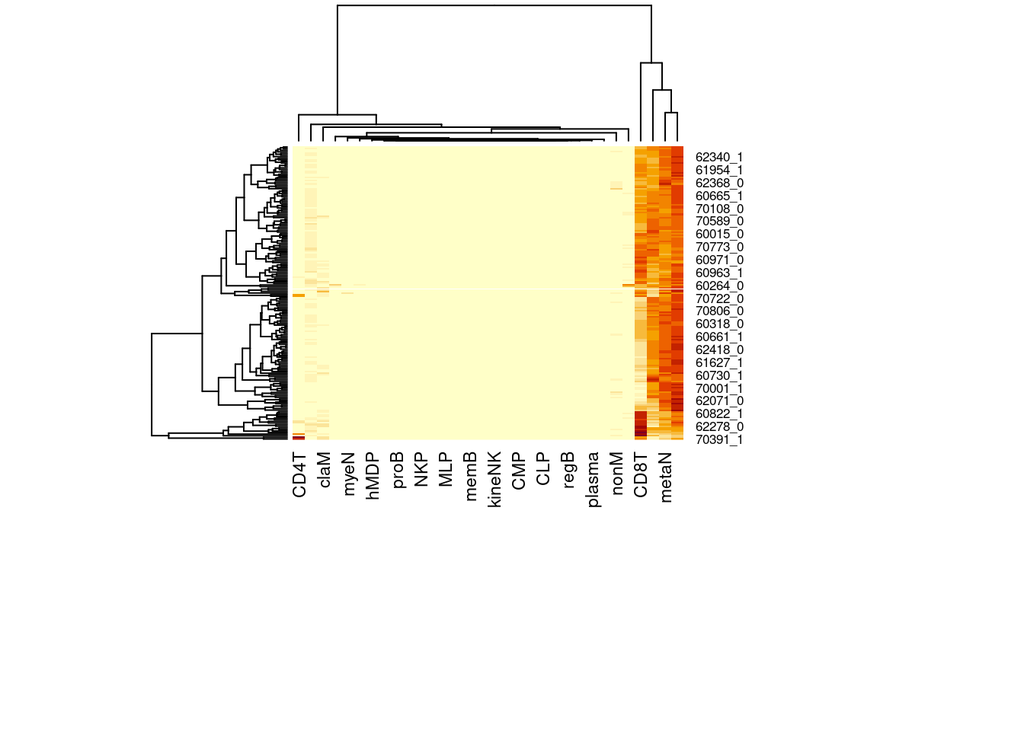

```r
heatmap(deconv, margins=c(12,8))
```

Save

```r
save(deconv, file="../GOTO_Data/Cell_Counts/Blood/GOTO_Blood-Music.Rdata")
```

### Add to targets

Make ID variable in targets

```r
targets <- targets %>%
  mutate(
    ID = paste0(IOP2_ID, "_",as.numeric(timepoint)-1)
  )
```

Make variable names

```r
colnames(deconv) <- paste0("cc_blood_music_", colnames(deconv))
```

Make percentages

```r
deconv <- as.data.frame(deconv) %>% mutate_if(is.numeric, ~ . * 100)
```

Make ID variable in deconv

```r
deconv <- as.data.frame(deconv) %>% rownames_to_column(var="ID")
```

Merge

```r
targets <- left_join(targets, deconv, by="ID")
```

Remove for non blood tissues

```r
targets <- targets %>%
  mutate(
    cc_blood_music_BNK = ifelse(
      tissue != "fasted blood", NA, cc_blood_music_BNK),
    cc_blood_music_CD4T = ifelse(
      tissue != "fasted blood", NA, cc_blood_music_CD4T),
    cc_blood_music_CD8T = ifelse(
      tissue != "fasted blood", NA, cc_blood_music_CD8T),
    cc_blood_music_claM = ifelse(
      tissue != "fasted blood", NA, cc_blood_music_claM),
    cc_blood_music_CLP = ifelse(
      tissue != "fasted blood", NA, cc_blood_music_CLP),
    cc_blood_music_cMOP = ifelse(
      tissue != "fasted blood", NA, cc_blood_music_cMOP),
    cc_blood_music_CMP = ifelse(
      tissue != "fasted blood", NA, cc_blood_music_CMP),
    cc_blood_music_ery = ifelse(
      tissue != "fasted blood", NA, cc_blood_music_ery),
    cc_blood_music_GMP = ifelse(
      tissue != "fasted blood", NA, cc_blood_music_GMP),
    cc_blood_music_hMDP = ifelse(
      tissue != "fasted blood", NA, cc_blood_music_hMDP),
    cc_blood_music_HSC = ifelse(
      tissue != "fasted blood", NA, cc_blood_music_HSC),
    cc_blood_music_immB = ifelse(
      tissue != "fasted blood", NA, cc_blood_music_immB),
    cc_blood_music_interM = ifelse(
      tissue != "fasted blood", NA, cc_blood_music_interM),
    cc_blood_music_kineNK = ifelse(
      tissue != "fasted blood", NA, cc_blood_music_kineNK),
    cc_blood_music_LMPP = ifelse(
      tissue != "fasted blood", NA, cc_blood_music_LMPP),
    cc_blood_music_matureN = ifelse(
      tissue != "fasted blood", NA, cc_blood_music_matureN),
    cc_blood_music_memB = ifelse(
      tissue != "fasted blood", NA, cc_blood_music_memB),
    cc_blood_music_MEP = ifelse(
      tissue != "fasted blood", NA, cc_blood_music_MEP),
    cc_blood_music_metaN = ifelse(
      tissue != "fasted blood", NA, cc_blood_music_metaN),
    cc_blood_music_MLP = ifelse(
      tissue != "fasted blood", NA, cc_blood_music_MLP),
    cc_blood_music_MPP = ifelse(
      tissue != "fasted blood", NA, cc_blood_music_MPP),
    cc_blood_music_myeN = ifelse(
      tissue != "fasted blood", NA, cc_blood_music_myeN),
    cc_blood_music_naiB = ifelse(
      tissue != "fasted blood", NA, cc_blood_music_naiB),
    cc_blood_music_NKP = ifelse(
      tissue != "fasted blood", NA, cc_blood_music_NKP),
    cc_blood_music_nonM = ifelse(
      tissue != "fasted blood", NA, cc_blood_music_nonM),
    cc_blood_music_plasma = ifelse(
      tissue != "fasted blood", NA, cc_blood_music_plasma),
    cc_blood_music_preB = ifelse(
      tissue != "fasted blood", NA, cc_blood_music_preB),
    cc_blood_music_preM = ifelse(
      tissue != "fasted blood", NA, cc_blood_music_preM),
    cc_blood_music_proB = ifelse(
      tissue != "fasted blood", NA, cc_blood_music_proB),
    cc_blood_music_proN = ifelse(
      tissue != "fasted blood", NA, cc_blood_music_proN),
    cc_blood_music_regB = ifelse(
      tissue != "fasted blood", NA, cc_blood_music_regB),
    cc_blood_music_toxiNK = ifelse(
      tissue != "fasted blood", NA, cc_blood_music_toxiNK),
  )
```

# IDOL

Save the RGset for blood only

```r
RGset_blood <- RGset[ , RGset$tissue == 'fasted blood']
```

Minfi

```r
hub <- ExperimentHub()
```

```
## snapshotDate(): 2022-10-31
```

```r
query(hub, "FlowSorted.Blood.EPIC")
```

```
## ExperimentHub with 1 record
## # snapshotDate(): 2022-10-31
## # names(): EH1136
## # package(): FlowSorted.Blood.EPIC
## # $dataprovider: GEO
## # $species: Homo sapiens
## # $rdataclass: RGChannelSet
## # $rdatadateadded: 2018-04-20
## # $title: FlowSorted.Blood.EPIC: Illumina Human Methylation data from EPIC o...
## # $description: The FlowSorted.Blood.EPIC package contains Illumina HumanMet...
## # $taxonomyid: 9606
## # $genome: hg19
## # $sourcetype: tar.gz
## # $sourceurl: https://www.ncbi.nlm.nih.gov/geo/query/acc.cgi?acc=GSE110554
## # $sourcesize: NA
## # $tags: c("ExperimentData", "Homo_sapiens_Data", "Tissue",
## #   "MicroarrayData", "Genome", "TissueMicroarrayData",
## #   "MethylationArrayData")
## # retrieve record with 'object[["EH1136"]]'
```

```r
FlowSorted.Blood.EPIC <- hub[["EH1136"]]
```

```
## see ?FlowSorted.Blood.EPIC and browseVignettes('FlowSorted.Blood.EPIC') for documentation
```

```
## loading from cache
```

Calculate cell counts

```
## [estimateCellCounts] Combining user data with reference (flow sorted) data.
```

```
## [estimateCellCounts] Processing user and reference data together.
```

```
## [preprocessQuantile] Mapping to genome.
```

```
## [preprocessQuantile] Fixing outliers.
```

```
## [preprocessQuantile] Quantile normalizing.
```

```
## [estimateCellCounts] Picking probes for composition estimation.
```

```
## [estimateCellCounts] Estimating composition.
```

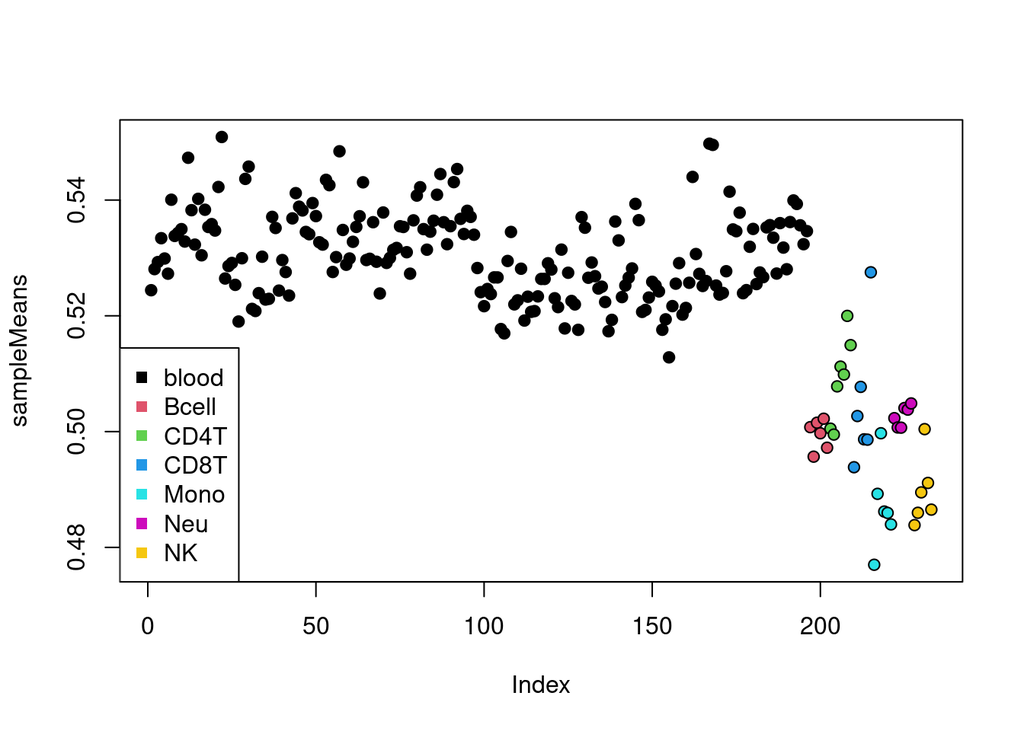

```r
idol_blood <- estimateCellCounts(
  rgSet = RGset_blood,
  referencePlatform = 'IlluminaHumanMethylationEPIC',
  cellTypes = c("CD8T", "CD4T", "NK", "Bcell",
                                "Mono", "Neu"),
  verbose = TRUE, meanPlot = TRUE)
```

Save

```r
save(idol_blood,
     file="../GOTO_Data/Cell_Counts/Blood/GOTO_Blood-IDOL.Rdata")
```

### Join with targets

Create merging variable

```r
idol_blood <- as.data.frame(idol_blood) %>%
  rownames_to_column(var = 'Basename')
summary(idol_blood)
```

```
##    Basename              CD8T              CD4T               NK
##  Length:196         Min.   :0.03718   Min.   :0.03219   Min.   :0.00370
##  Class :character   1st Qu.:0.10224   1st Qu.:0.12119   1st Qu.:0.03752
##  Mode  :character   Median :0.12223   Median :0.16240   Median :0.05209
##                     Mean   :0.13009   Mean   :0.15779   Mean   :0.05783
##                     3rd Qu.:0.15545   3rd Qu.:0.19628   3rd Qu.:0.07413
##                     Max.   :0.28816   Max.   :0.33827   Max.   :0.24852
##      Bcell              Mono              Neu
##  Min.   :0.01079   Min.   :0.04267   Min.   :0.1633
##  1st Qu.:0.04604   1st Qu.:0.08572   1st Qu.:0.4720
##  Median :0.06048   Median :0.09969   Median :0.5201
##  Mean   :0.06562   Mean   :0.10159   Mean   :0.5179
##  3rd Qu.:0.07527   3rd Qu.:0.11647   3rd Qu.:0.5723
##  Max.   :0.45958   Max.   :0.19203   Max.   :0.7167
```

Make percentages

```r
idol_blood <- idol_blood %>% mutate_if(is.numeric, ~ . * 100)
```

Column names

```r
colnames(idol_blood) <- c("Basename", "cc_blood_idol_CD8T",
                          "cc_blood_idol_CD4T",
                          "cc_blood_idol_NK",
                          "cc_blood_idol_Bcell",
                          "cc_blood_idol_Mono",
                          "cc_blood_idol_Neu")
```

Merge

```r
targets <- left_join(targets, idol_blood, by="Basename")
```

# IDOL Extended

Load data

```r
load("../GOTO_Data/Cell_Counts/Blood/GOTO_Blood-IDOLext.Rdata")
```

Make percentages

```r
idol_ext <- idol_ext %>% mutate_if(is.numeric, ~ . * 100)
```

Look at it

```r
summary(idol_ext)
```

```
##       Bas              Bmem             Bnv            CD4mem
##  Min.   :0.0000   Min.   : 0.000   Min.   :0.000   Min.   : 0.570
##  1st Qu.:0.0300   1st Qu.: 1.127   1st Qu.:2.485   1st Qu.: 7.862
##  Median :0.6700   Median : 1.630   Median :3.405   Median :10.560
##  Mean   :0.7264   Mean   : 2.345   Mean   :3.639   Mean   :10.594
##  3rd Qu.:1.0825   3rd Qu.: 2.312   3rd Qu.:4.582   3rd Qu.:12.835
##  Max.   :4.9600   Max.   :48.990   Max.   :9.350   Max.   :24.820
##      CD4nv            CD8mem           CD8nv             Eos
##  Min.   : 0.000   Min.   : 0.000   Min.   :0.0000   Min.   : 0.0000
##  1st Qu.: 3.167   1st Qu.: 3.915   1st Qu.:0.0000   1st Qu.: 0.5125
##  Median : 6.765   Median : 5.910   Median :0.0000   Median : 1.5750
##  Mean   : 6.748   Mean   : 7.232   Mean   :0.8024   Mean   : 2.3382
##  3rd Qu.: 9.682   3rd Qu.: 9.180   3rd Qu.:1.1625   3rd Qu.: 3.1450
##  Max.   :18.780   Max.   :36.450   Max.   :5.6700   Max.   :12.3900
##       Mono             Neu              NK              Treg
##  Min.   : 2.690   Min.   :10.79   Min.   : 0.000   Min.   :0.0000
##  1st Qu.: 5.928   1st Qu.:41.97   1st Qu.: 3.958   1st Qu.:0.5475
##  Median : 7.280   Median :47.98   Median : 5.190   Median :1.1550
##  Mean   : 7.369   Mean   :47.64   Mean   : 5.521   Mean   :1.2803
##  3rd Qu.: 8.545   3rd Qu.:53.74   3rd Qu.: 6.520   3rd Qu.:1.8375
##  Max.   :14.140   Max.   :74.11   Max.   :15.840   Max.   :4.3900
```

Create join variable

```r
idol_ext <- idol_ext %>% rownames_to_column(var="Basename")
```

Set colnames

```r
colnames(idol_ext) <- c("Basename", "cc_blood_ext_Bas",
                        "cc_blood_ext_Bmem", "cc_blood_ext_Bnv",
                        "cc_blood_ext_CD4mem", "cc_blood_ext_CD4nv",
                        "cc_blood_ext_CD8mem", "cc_blood_ext_CD8nv",
                        "cc_blood_ext_Eos", "cc_blood_ext_Mono",
                        "cc_blood_ext_Neu", "cc_blood_ext_NK",
                        "cc_blood_ext_Treg")
```

Merge

```r
targets <- left_join(targets, idol_ext, by="Basename")
```

# Add to methData and RGset

```r
check <- targets$Basename == colnames(methData)
xtabs(~check)
```

```
## check
## TRUE
##  534
```

```r
check <- targets$Basename == colnames(RGset)
xtabs(~check)
```

```
## check
## TRUE
##  534
```

```r
check <- colnames(RGset) == colnames(methData)
xtabs(~check)
```

```
## check
## TRUE
##  534
```

Reorder targets

```r
order <- colnames(methData)

targets <- targets[match(order, targets$Basename),]
rownames(targets) <- targets$Basename
```

```r
colData(methData) <- DataFrame(targets)
colData(RGset) <- DataFrame(targets)
```

Look

```r
methData
```

```
## class: SummarizedExperiment
## dim: 755777 534
## metadata(0):
## assays(1): beta
## rownames(755777): cg18478105 cg09835024 ... cg10633746 cg12623625
## rowData names(57): cpg chr ... MASK_extBase MASK_general
## colnames(534): 203527980082_R01C01 203527980082_R02C01 ...
##   203550300093_R07C01 203550300093_R08C01
## colData names(102): DNA_labnr IOP2_ID ... cc_blood_ext_NK
##   cc_blood_ext_Treg
```

```r
RGset
```

```
## class: RGChannelSetExtended
## dim: 1051815 534
## metadata(0):
## assays(5): Green Red GreenSD RedSD NBeads
## rownames(1051815): 1600101 1600111 ... 99810990 99810992
## rowData names(0):
## colnames(534): 203527980082_R01C01 203527980082_R02C01 ...
##   203550300093_R07C01 203550300093_R08C01
## colData names(102): DNA_labnr IOP2_ID ... cc_blood_ext_NK
##   cc_blood_ext_Treg
## Annotation
##   array: IlluminaHumanMethylationEPIC
##   annotation: ilm10b4.hg19
```

Save

```r
save(targets, file="../GOTO_Data/GOTO_targets-filtered.Rdata")
save(methData, file="../GOTO_Data/GOTO_methData-filtered.Rdata")
```

Clear

```r
rm(list=ls())
```